# UFSCar-ACIEPE

Análise e visualização de dados do coronavírus usando R.

Sergio Lima

Oct 14, 2020

## Homework 02

#### 1) Utilizando o conjunto de dados USArrests descrito na aula

- Construa um histograma para cada uma das variaveis contidas nesse banco de dados.
- Use uma cor diferente para cada histograma.
- Construa tambem box-plots para cada uma das variaveis, com as mesmas cores usadas no histograma.

```r
# Carregar dataset USArrests
data(USArrests)
usa_arrest_dataset = USArrests
# Quantas variaveis existem neste dataset?
# linhas e colunas
dim(usa_arrest_dataset)
```

```
## [1] 50  4
```

```r
# nomes das variáveis
names(usa_arrest_dataset)
```

```
## [1] "Murder"   "Assault"  "UrbanPop" "Rape"
```

- Histograma para variavel Murder

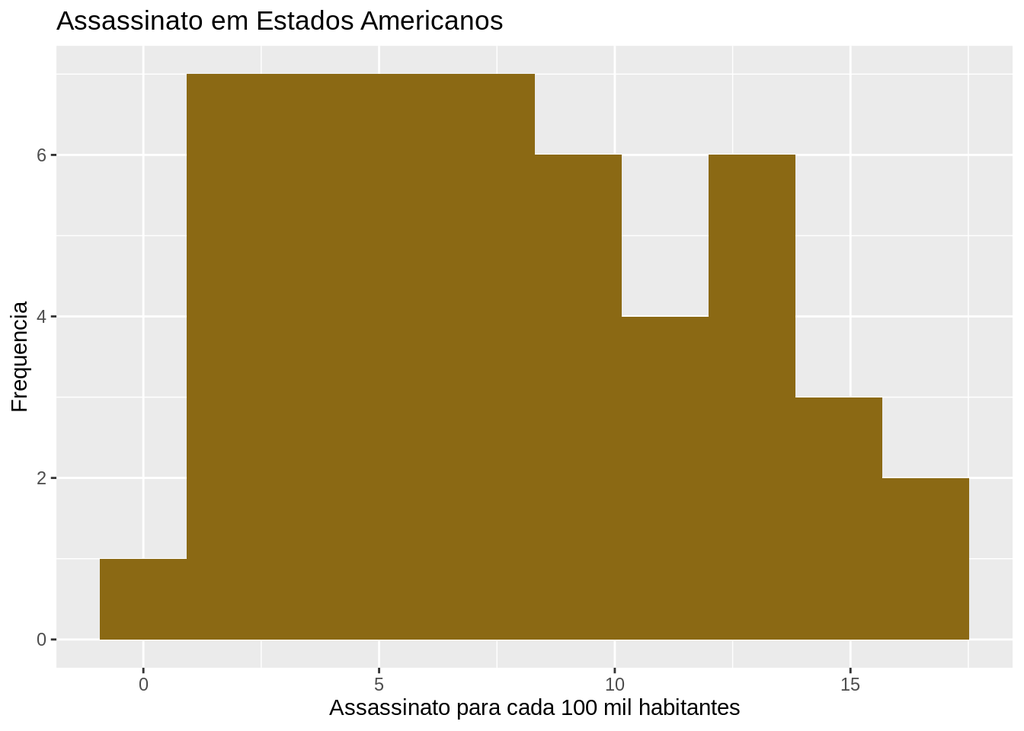

```r
ggplot(usa_arrest_dataset) +
geom_histogram(mapping = aes(x = Murder), bins = 10, fill ='goldenrod4') +
labs(x = 'Assassinato para cada 100 mil habitantes',
y = 'Frequencia',
title = 'Assassinato em Estados Americanos')
```

- Diagrama de caixa ou box-plot (quartis da distribuição, onde podemos analisar a dispersão da variável)

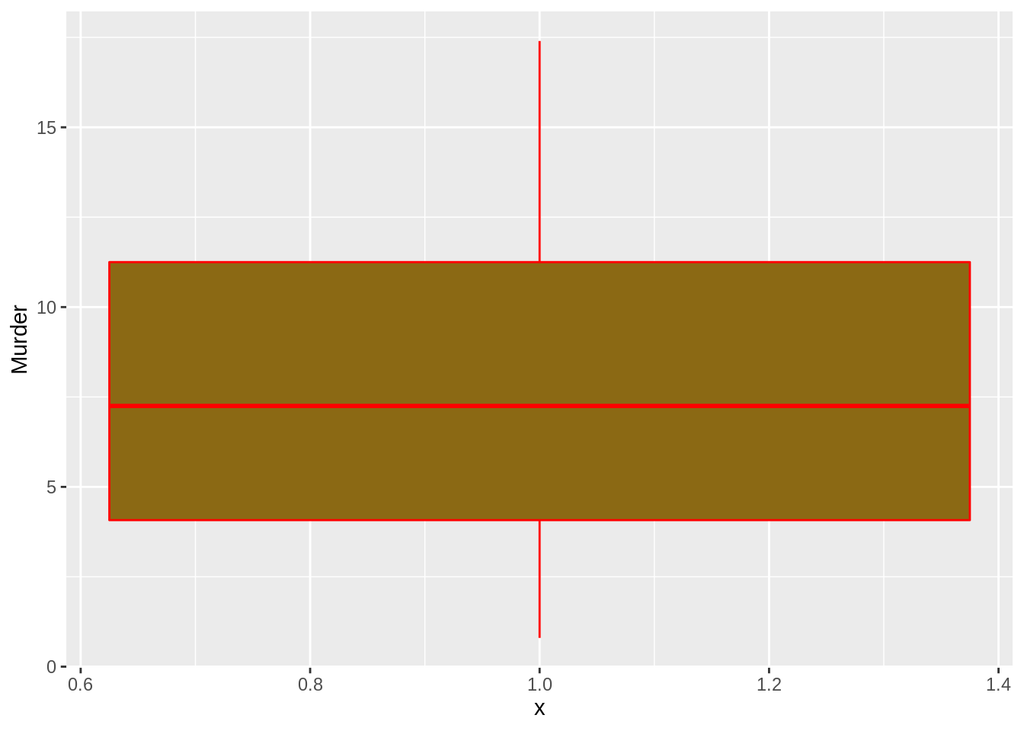

```r
ggplot(data = usa_arrest_dataset) +
geom_boxplot(mapping = aes(x = 1, y = Murder), color = 'red', fill = 'goldenrod4')
```

- Histograma para variavel Assault

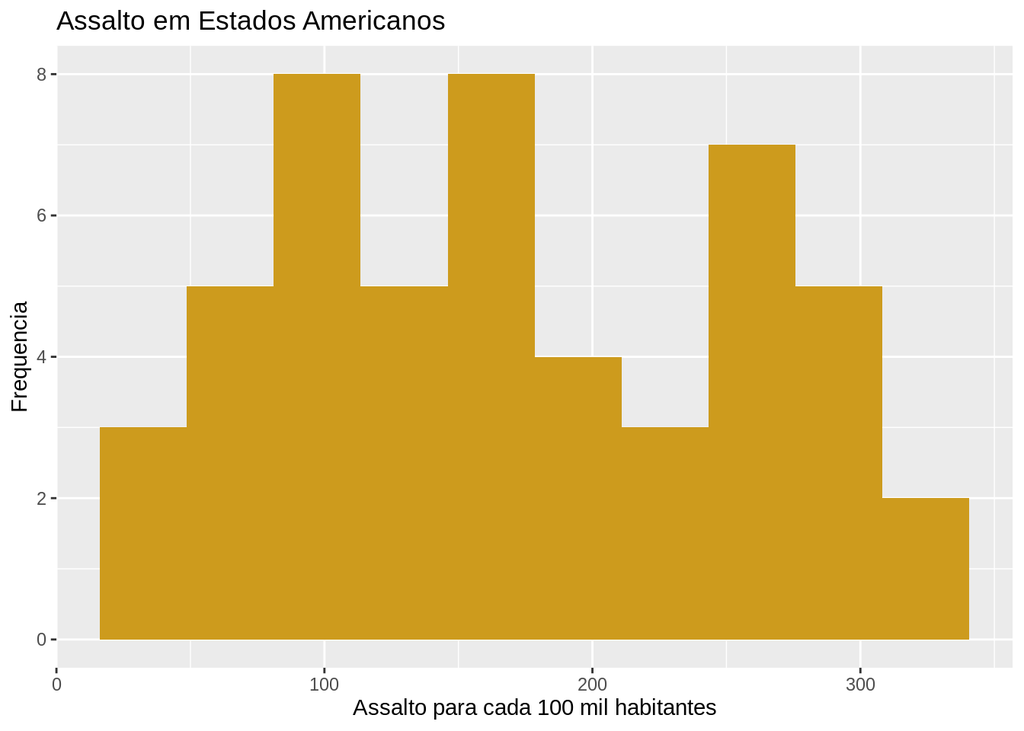

```r
ggplot(usa_arrest_dataset) +
geom_histogram(mapping = aes(x = Assault), bins = 10, fill ='goldenrod3') +
labs(x = 'Assalto para cada 100 mil habitantes',
y = 'Frequencia',
title = 'Assalto em Estados Americanos')
```

- Diagrama de caixa ou box-plot (quartis da distribuição, onde podemos analisar a dispersão da variável)

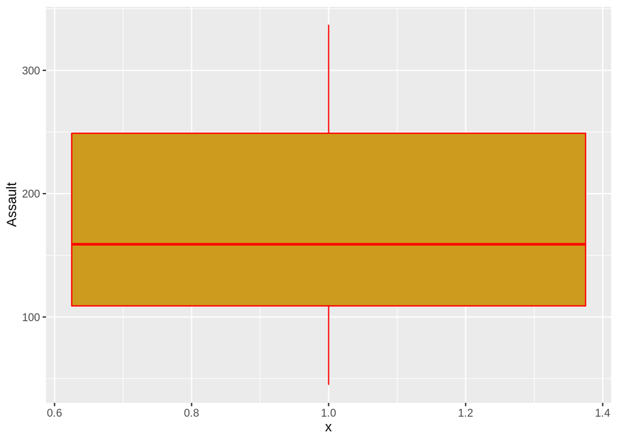

```r
ggplot(data = usa_arrest_dataset) +
geom_boxplot(mapping = aes(x = 1, y = Assault), color = 'red', fill = 'goldenrod3')
```

- Histograma para variavel UrbanPop

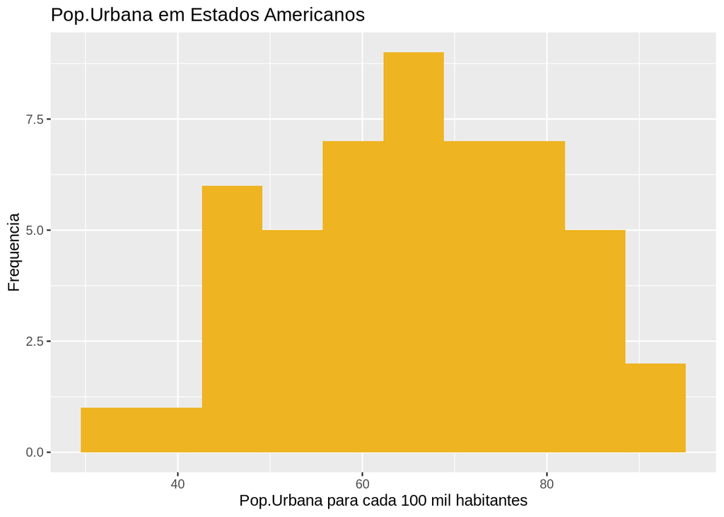

```r
ggplot(usa_arrest_dataset) +
geom_histogram(mapping = aes(x = UrbanPop), bins = 10, fill ='goldenrod2') +
labs(x = 'Pop.Urbana para cada 100 mil habitantes',
y = 'Frequencia',
title = 'Pop.Urbana em Estados Americanos')
```

- Diagrama de caixa ou box-plot (quartis da distribuição, onde podemos analisar a dispersão da variável)

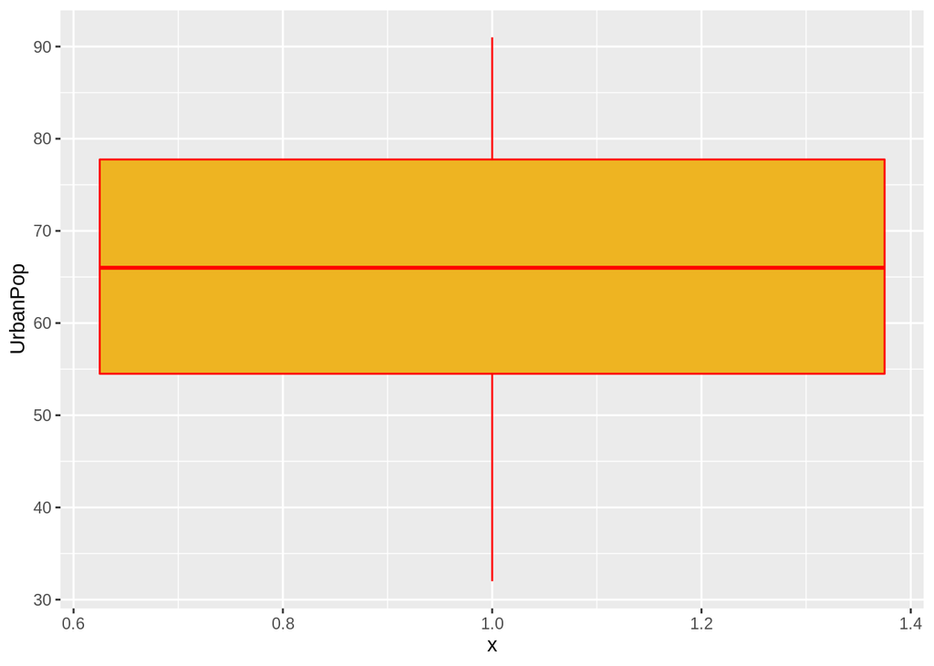

```r
ggplot(data = usa_arrest_dataset) +
geom_boxplot(mapping = aes(x = 1, y = UrbanPop), color = 'red', fill = 'goldenrod2')
```

- Histograma para variavel Rape

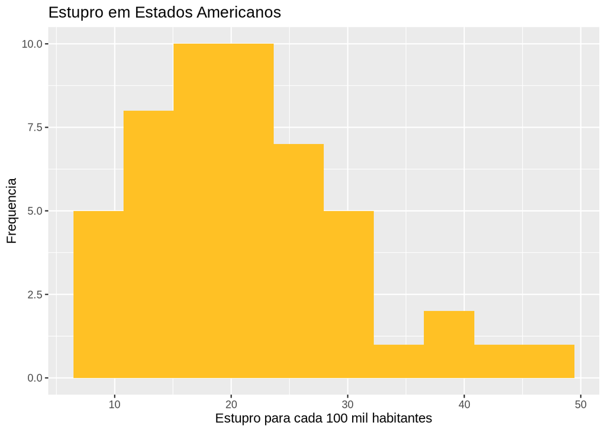

```r
ggplot(usa_arrest_dataset) +
geom_histogram(mapping = aes(x = Rape), bins = 10, fill ='goldenrod1') +
labs(x = 'Estupro para cada 100 mil habitantes',
y = 'Frequencia',
title = 'Estupro em Estados Americanos')
```

- Diagrama de caixa ou box-plot (quartis da distribuição, onde podemos analisar a dispersão da variável)

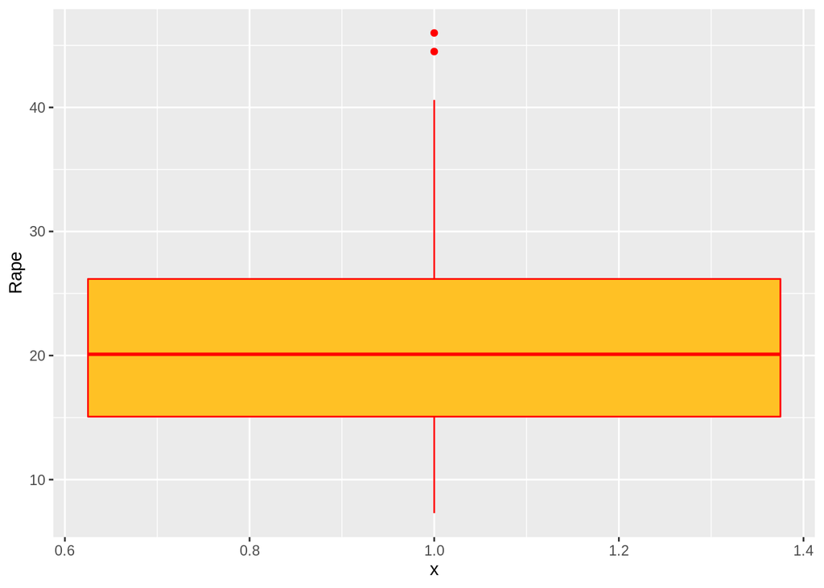

```r
ggplot(data = usa_arrest_dataset) +
geom_boxplot(mapping = aes(x = 1, y = Rape), color = 'red', fill = 'goldenrod1')
```

#### 2) Escolha duas variaveis do banco de dados para fazer um diagrama de dispersao (scatterplot), usando geom point.

- Acrescente uma linha relacionando as duas variaveis para ajudar na interpretacao.
- Descreva o fenomeno que voce quer analisar com esse diagrama.

Gráfico de dispersão (scatterplot) com geom_point. Verificar como o nível de estupros se relaciona com o tamanho da população urbana.

[figure not shown]

```r
ggplot(usa_arrest_dataset, aes(x = Rape, y = UrbanPop)) +
geom_point(mapping = aes(x = Rape), color='blue', size=4) +
  labs(y = "Estupros",
    x = "População Urbana",
    title = "Relação entre Estupros e População Urbana") +
geom_smooth(se = FALSE, method = "lm") # <-- geom_smooth para acrescentar uma linha no grafico
```

#### 3) Utilizando a função data() do R, escolha um conjunto de dados de sua preferencia

- Crie 4 gráficos, a sua escolha, usando as variáveis deste banco de dados.
- Faça uma breve interpretação de seus achados.

```r
# Carregar dataset mpg.
# Dados de economia de combustível de 1999 a 2008 para 38 modelos populares de carros
# Contém apenas modelos que tiveram um novo lançamento a cada ano entre 1999 e 2008.
# isso foi usado como um proxy para a popularidade do carro.
data(mpg)
mpg_dataset = mpg
# Quantas variaveis existem neste dataset?
# linhas e colunas
dim(mpg_dataset)
```

```
## [1] 234  11
```

```r
# nomes das variáveis
names(mpg_dataset)
```

```
##  [1] "manufacturer" "model"        "displ"        "year"         "cyl"
##  [6] "trans"        "drv"          "cty"          "hwy"          "fl"
## [11] "class"
```

- 4 gráficos usando as variáveis deste banco de dados.
- Breve Interpretacao:
- O gráfico mostra uma possível relação negativa entre eficiência (milhas por galao na cidade) e cilindradas.

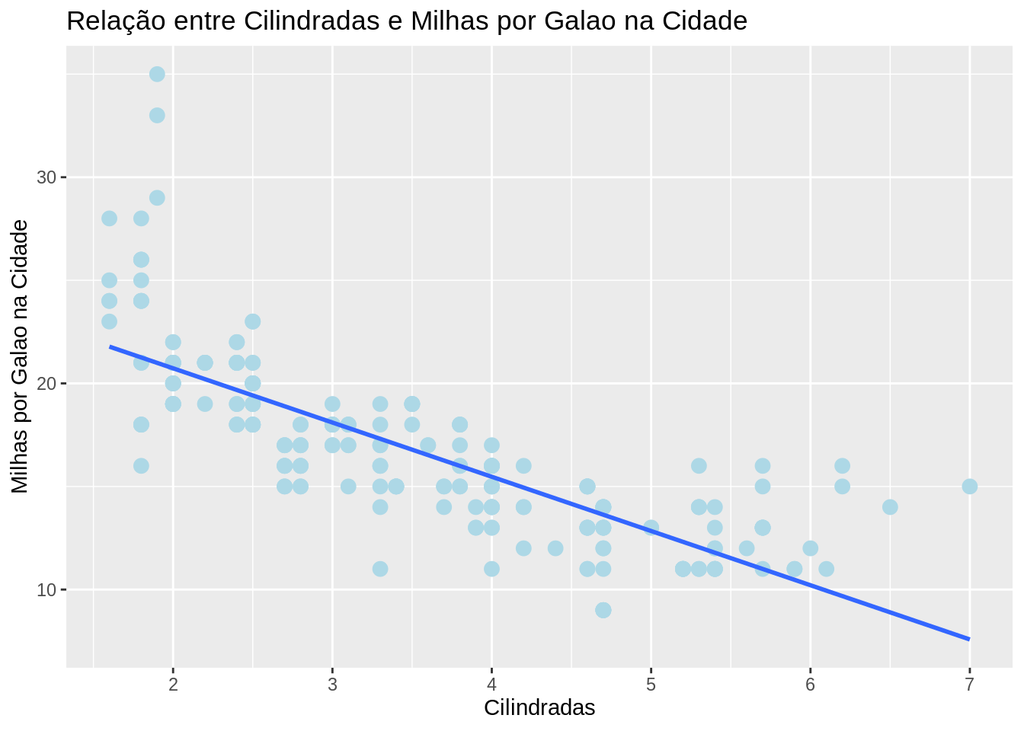

```r
ggplot(mpg_dataset, aes(x = displ, y = cty)) +
geom_point(mapping = aes(x = displ), color = 'lightblue', size = 3) +
labs(y = "Milhas por Galao na Cidade",
  x = "Cilindradas",
  title = "Relação entre Cilindradas e Milhas por Galao na Cidade") +
geom_smooth(se = FALSE, method = "lm")  # <-- geom_smooth para acrescentar uma linha no grafico
```

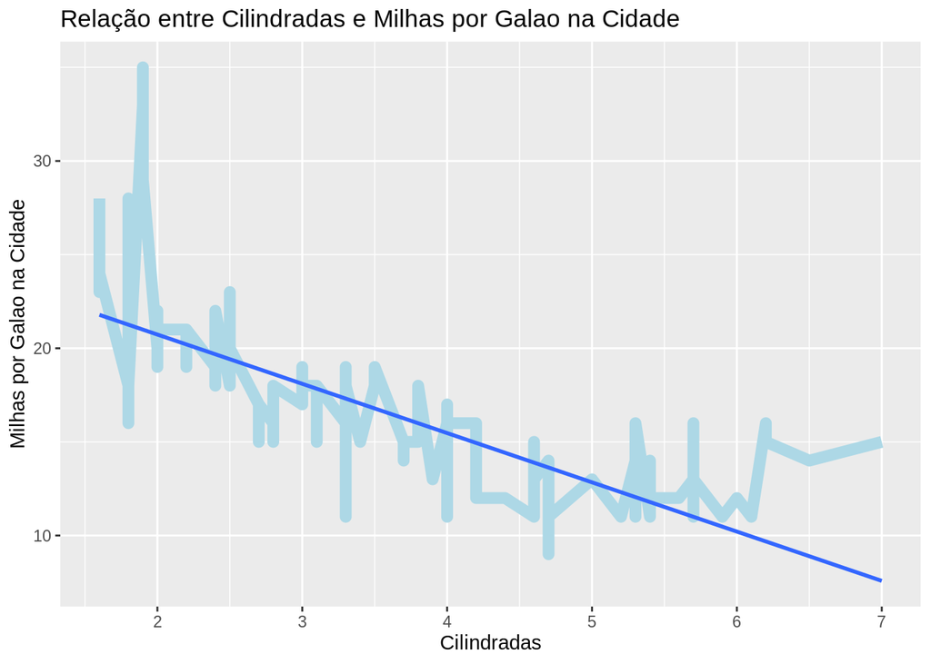

```r
ggplot(mpg_dataset, aes(x = displ, y = cty)) +
geom_line(mapping = aes(x = displ), color = 'lightblue', size = 3) +
labs(y = "Milhas por Galao na Cidade",
  x = "Cilindradas",
  title = "Relação entre Cilindradas e Milhas por Galao na Cidade") +
geom_smooth(se = FALSE, method = "lm")  # <-- geom_smooth para acrescentar uma linha no grafico
```

[figure not shown]

```r
ggplot(mpg_dataset) +
geom_histogram(mapping = aes(x = displ), bins = 6, fill =rainbow(6), color='black') +
labs(y = "Milhas por Galao na Cidade",
  x = "Cilindradas",
  title = "Relação entre Cilindradas e Milhas por Galao na Cidade")
```

[figure not shown]

```r
ggplot(mpg_dataset) +
geom_density(mapping = aes(x = displ), kernel = 'gaussian') +
labs(y = "Milhas por Galao na Cidade",
  x = "Cilindradas",
  title = "Relação entre Cilindradas e Milhas por Galao na Cidade")
```

#### 4) Considerando o banco de dados utilizado no exercicio anterior, escolha duas variaveis para analisar via diagrama de dispersao.

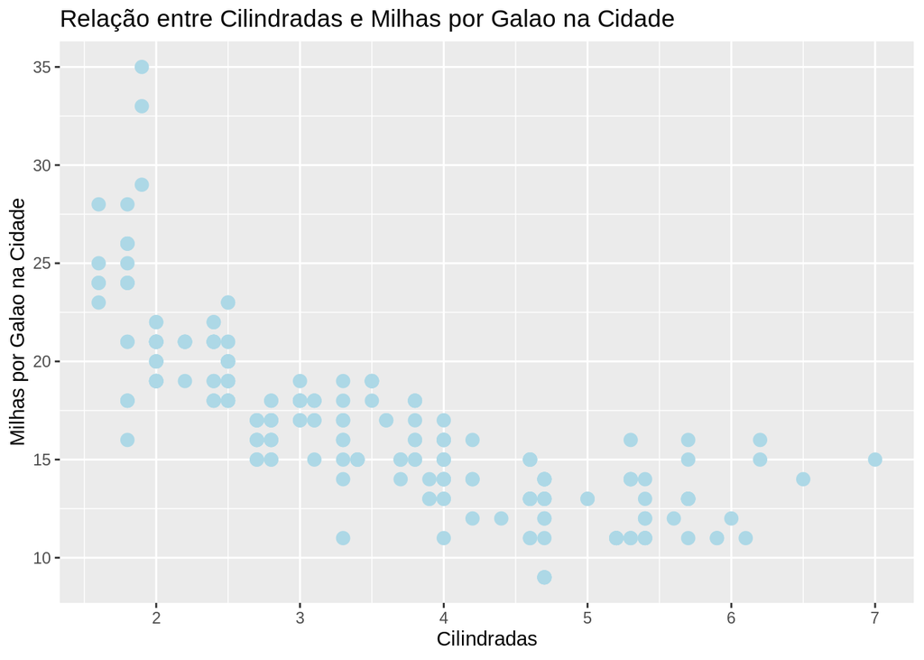

```r
ggplot(mpg_dataset, aes(x = displ, y = cty)) +
geom_point(mapping = aes(x = displ), color = 'lightblue', size = 3) +
labs(y = "Milhas por Galao na Cidade",
  x = "Cilindradas",
  title = "Relação entre Cilindradas e Milhas por Galao na Cidade")
```

#### 5) Utilize o comando ?mpg e descreva as variaveis contidas neste banco de dados.

- Faca um analise preliminar deste banco de dados usando os comando head, tail, etc (como fizemos para USArrests).

```r
?mpg
```

- Analise preliminar deste banco de dados:

```r
mpg_dataset = mpg
str(mpg_dataset) # amostra de valores
```

```
## tibble [234 × 11] (S3: tbl_df/tbl/data.frame)
##  $ manufacturer: chr [1:234] "audi" "audi" "audi" "audi" ...
##  $ model       : chr [1:234] "a4" "a4" "a4" "a4" ...
##  $ displ       : num [1:234] 1.8 1.8 2 2 2.8 2.8 3.1 1.8 1.8 2 ...
##  $ year        : int [1:234] 1999 1999 2008 2008 1999 1999 2008 1999 1999 2008 ...
##  $ cyl         : int [1:234] 4 4 4 4 6 6 6 4 4 4 ...
##  $ trans       : chr [1:234] "auto(l5)" "manual(m5)" "manual(m6)" "auto(av)" ...
##  $ drv         : chr [1:234] "f" "f" "f" "f" ...
##  $ cty         : int [1:234] 18 21 20 21 16 18 18 18 16 20 ...
##  $ hwy         : int [1:234] 29 29 31 30 26 26 27 26 25 28 ...
##  $ fl          : chr [1:234] "p" "p" "p" "p" ...
##  $ class       : chr [1:234] "compact" "compact" "compact" "compact" ...
```

```r
dim(mpg_dataset) # dimensao (linhas e colunas)
```

```
## [1] 234  11
```

```r
head(mpg_dataset) # seis primeiras linhas
```

```
## # A tibble: 6 x 11
##   manufacturer model displ  year   cyl trans      drv     cty   hwy fl    class
##   <chr>        <chr> <dbl> <int> <int> <chr>      <chr> <int> <int> <chr> <chr>
## 1 audi         a4      1.8  1999     4 auto(l5)   f        18    29 p     compa…
## 2 audi         a4      1.8  1999     4 manual(m5) f        21    29 p     compa…
## 3 audi         a4      2    2008     4 manual(m6) f        20    31 p     compa…
## 4 audi         a4      2    2008     4 auto(av)   f        21    30 p     compa…
## 5 audi         a4      2.8  1999     6 auto(l5)   f        16    26 p     compa…
## 6 audi         a4      2.8  1999     6 manual(m5) f        18    26 p     compa…
```

```r
tail(mpg_dataset) # seis últimas linhas
```

```
## # A tibble: 6 x 11
##   manufacturer model  displ  year   cyl trans     drv     cty   hwy fl    class
##   <chr>        <chr>  <dbl> <int> <int> <chr>     <chr> <int> <int> <chr> <chr>
## 1 volkswagen   passat   1.8  1999     4 auto(l5)  f        18    29 p     midsi…
## 2 volkswagen   passat   2    2008     4 auto(s6)  f        19    28 p     midsi…
## 3 volkswagen   passat   2    2008     4 manual(m… f        21    29 p     midsi…
## 4 volkswagen   passat   2.8  1999     6 auto(l5)  f        16    26 p     midsi…
## 5 volkswagen   passat   2.8  1999     6 manual(m… f        18    26 p     midsi…
## 6 volkswagen   passat   3.6  2008     6 auto(s6)  f        17    26 p     midsi…
```

```r
summary(mpg_dataset) # sumário estatístico
```

```
##  manufacturer          model               displ            year
##  Length:234         Length:234         Min.   :1.600   Min.   :1999
##  Class :character   Class :character   1st Qu.:2.400   1st Qu.:1999
##  Mode  :character   Mode  :character   Median :3.300   Median :2004
##                                        Mean   :3.472   Mean   :2004
##                                        3rd Qu.:4.600   3rd Qu.:2008
##                                        Max.   :7.000   Max.   :2008
##       cyl           trans               drv                 cty
##  Min.   :4.000   Length:234         Length:234         Min.   : 9.00
##  1st Qu.:4.000   Class :character   Class :character   1st Qu.:14.00
##  Median :6.000   Mode  :character   Mode  :character   Median :17.00
##  Mean   :5.889                                         Mean   :16.86
##  3rd Qu.:8.000                                         3rd Qu.:19.00
##  Max.   :8.000                                         Max.   :35.00
##       hwy             fl               class
##  Min.   :12.00   Length:234         Length:234
##  1st Qu.:18.00   Class :character   Class :character
##  Median :24.00   Mode  :character   Mode  :character
##  Mean   :23.44
##  3rd Qu.:27.00
##  Max.   :44.00
```

```r
names(mpg_dataset) # nomes das variáveis
```

```
##  [1] "manufacturer" "model"        "displ"        "year"         "cyl"
##  [6] "trans"        "drv"          "cty"          "hwy"          "fl"
## [11] "class"
```

#### 6) Faça um gráfico de dispersão entre as variáveis hwy e cyl.

- Mude a cor do tema. Interprete os resultados.
- Gráfico de dispersão (scatterplot) com geom_point.
- Verificar numero de cilindros dos veiculos por desempenho na estrada.

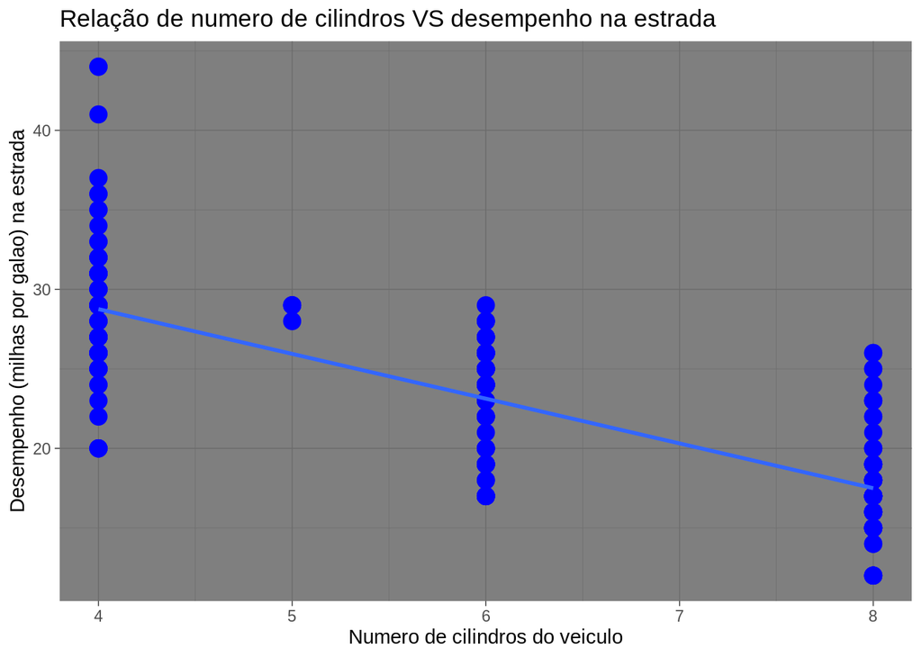

```r
ggplot(mpg_dataset, aes(x = cyl, y = hwy)) +
geom_point(mapping = aes(x = cyl), color='blue', size=4) +
labs(y = "Desempenho (milhas por galao) na estrada",
x = "Numero de cilindros do veiculo",
title = "Relação de numero de cilindros VS desempenho na estrada") +
geom_smooth(se = FALSE, method = "lm") + # <-- geom_smooth para acrescentar uma linha no grafico
theme_dark()
```

#### 7) Escolha duas variáveis do banco de dados e construa histograma e box-plot para elas.

- Personalize os gráficos usando cores diferentes do default.
- Não se esqueça de dar nomes para os eixos, bem como um título para os gráficos.
- Organize os gráficos em subplots usando grid.arrange().
- Note que:
- teremos 2 histogramas e 2 boxplots,
- totalizando 4 gráficos que vc deve plotar em duas colunas.

```r
#install.packages("gridExtra")
library(gridExtra)
```

- 4 gráficos

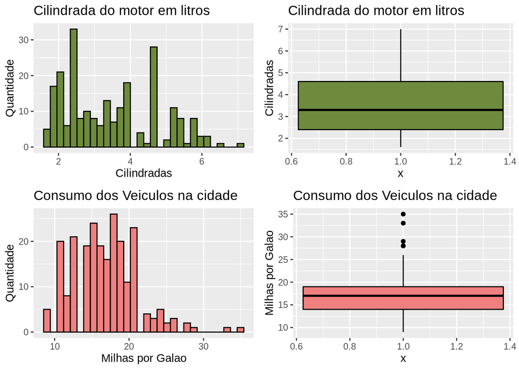

```r
histogran_01 <- ggplot(mpg_dataset) +
  geom_histogram(mapping = aes(x = displ), fill = 'darkolivegreen4', color='black') +
  labs(x = 'Cilindradas',
       y = 'Quantidade',
       title = 'Cilindrada do motor em litros')

box_plot_01 <- ggplot(mpg_dataset) +
  geom_boxplot(mapping = aes(x = 1, y = displ), fill = 'darkolivegreen4', color='black') +
  labs(y = 'Cilindradas',
       title = 'Cilindrada do motor em litros')

histogran_02 <- ggplot(mpg_dataset) +
  geom_histogram(mapping = aes(x = cty), fill = 'lightcoral', color='black') +
  labs(x = 'Milhas por Galao',
       y = 'Quantidade',
       title = 'Consumo dos Veiculos na cidade')

box_plot_02 <- ggplot(mpg_dataset) +
  geom_boxplot(mapping = aes(x = 1, y = cty), fill = 'lightcoral', color='black') +
  labs(y = 'Milhas por Galao',
       title = 'Consumo dos Veiculos na cidade')

grid.arrange(histogran_01, box_plot_01, histogran_02, box_plot_02, ncol = 2)
```

#### 8) Usando o arquivo de dados mpg ainda, vamos agora treinar o uso do recurso facets.

- 1 - Faça gráficos de dispersão entre displ e hwy separados para cada classe de veículos.
- Use color = class para diferenciar por cor e
- facet_wrap(~ class, nrow = 2) para obter os subplots.

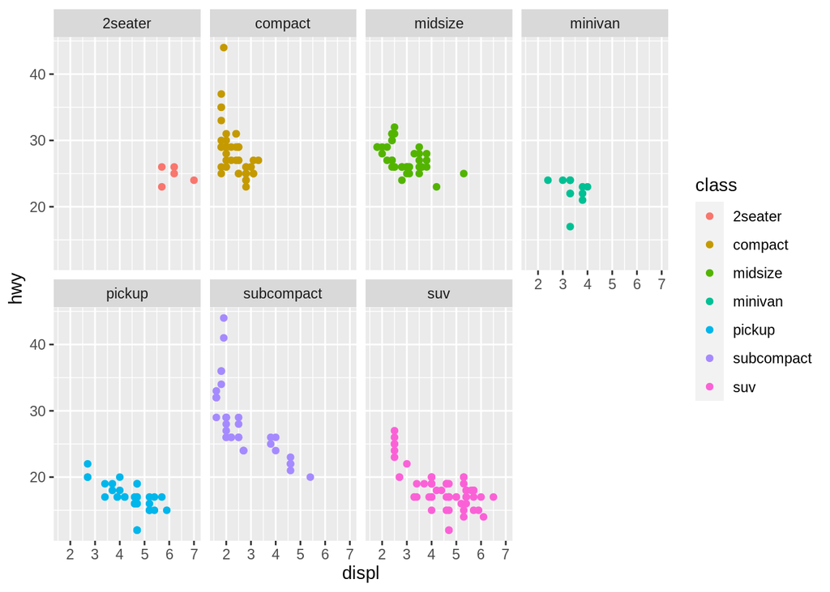

```r
ggplot(mpg_dataset) +
  geom_point(mapping = aes(x = displ, y = hwy, color = class)) +
  facet_wrap(~ class, nrow = 2)
```

- 2 - Agora vamos criar subplots com base em duas variáveis: número de cilindros (cyl) e tipo de direção (drv).
- Diferencie por cor usando color=drv e utilize facet_grid(drv ∼ cyl).
- Algumas facetas ficarão vazias por não possuírem combinações de drv e cyl.

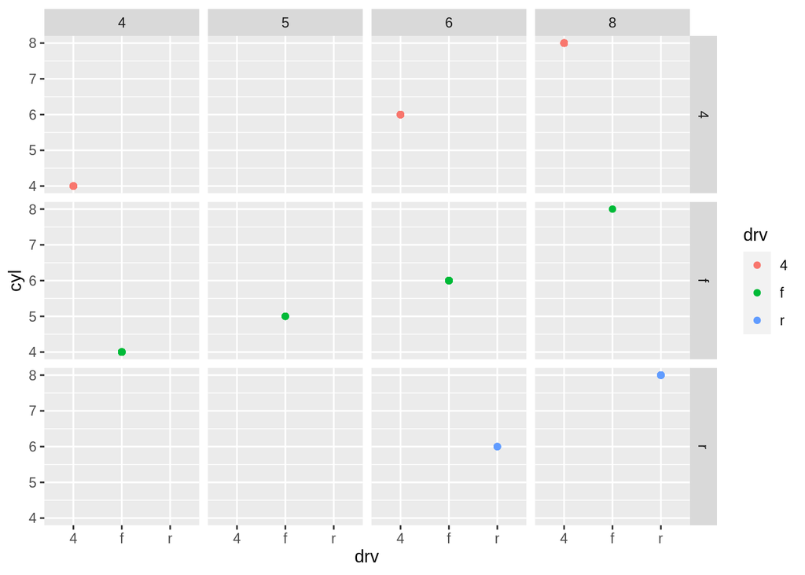

```r
ggplot(mpg_dataset) +
  geom_point(mapping = aes(x = drv, y = cyl, color = drv)) +
  facet_grid(drv ~ cyl)
```

- 3 Explique o que ocorre se você usar color=cyl para classifcar por cilindros (cyl) e facet_grid(. ∼ cyl)
- Resposta: desta forma, o grafico criou legenda por cyl (cilindros) e nao criou divisoes no grafico por drv.

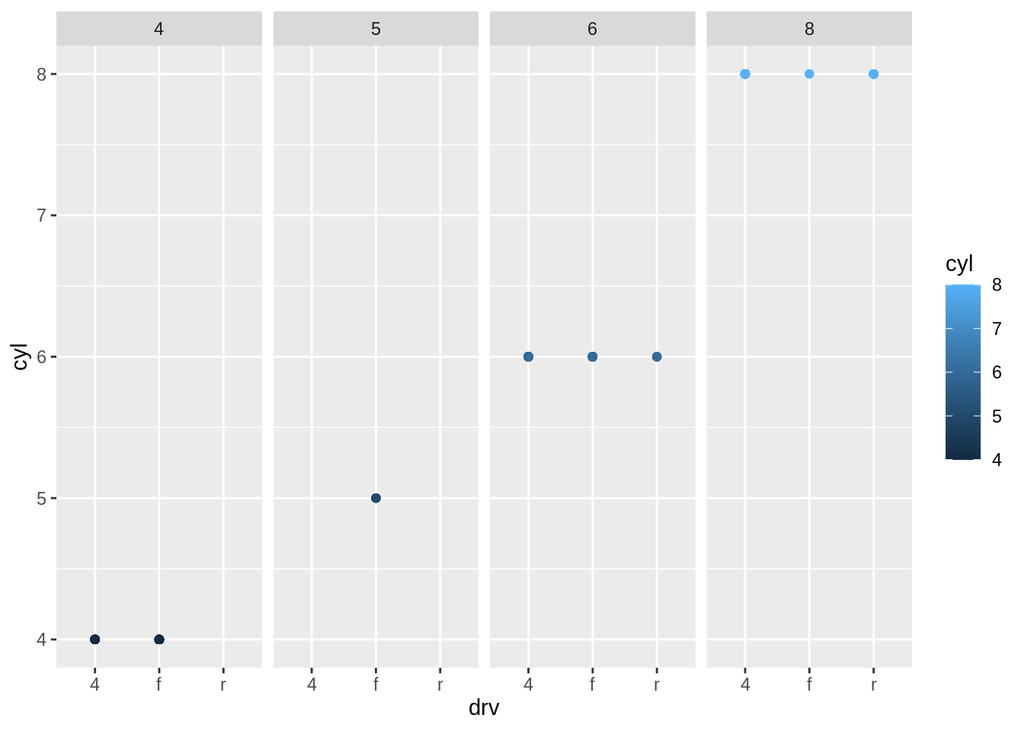

```r
ggplot(mpg_dataset) +
  geom_point(mapping = aes(x = drv, y = cyl, color = cyl)) +
  facet_grid(. ~ cyl)
```

```r
library(readxl)
homework2 = read_excel("homework2.xlsx")
```

- Lembre-se de salvar o arquivo na pasta usada como diretório do R.
- Os dados dizem respeito basicamente ao indice de desenvolvimento humano (HDI) e percepção da corrupção (CPI)
1. Construa um diagrama de dispersão entre as variáveis CPI (eixo x) e HDI (eixo y). Coloque a cor vermelha nos pontos.

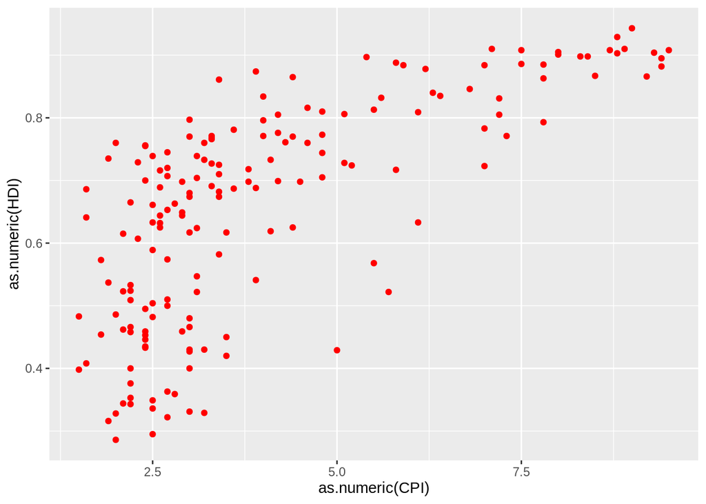

```r
ggplot(homework2, aes(y = as.numeric(HDI),  x = as.numeric(CPI))) +
  geom_point(color = 'red')
```

2. Agora diferencie a cor dos pontos por região.

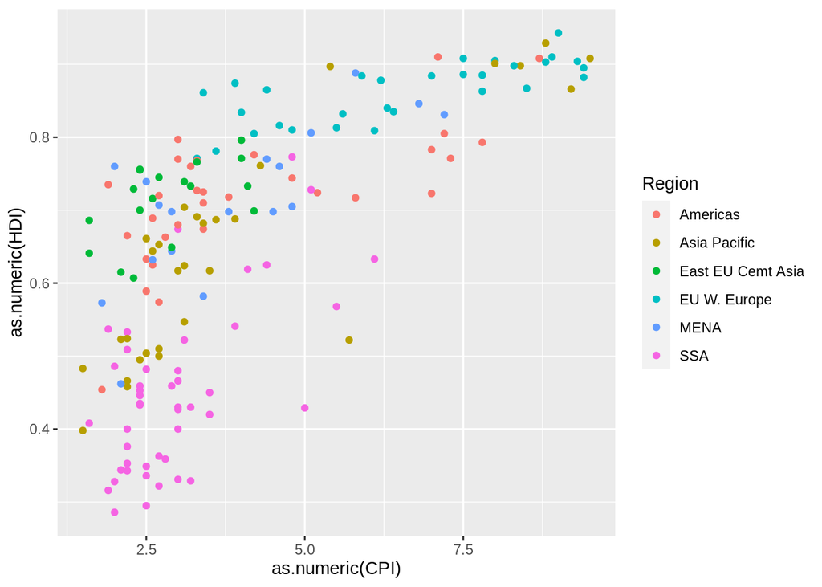

```r
ggplot(homework2, aes(y = as.numeric(HDI),  x = as.numeric(CPI))) +
  geom_point(aes(color = Region))
```

3. Faça um gráfico com pontos maiores (size =3).

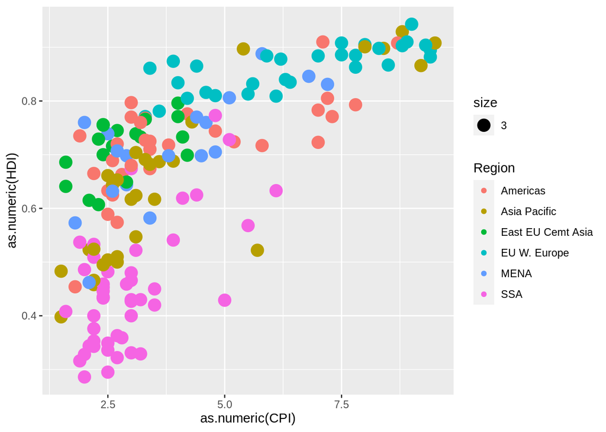

```r
ggplot(homework2, aes(y = as.numeric(HDI),  x = as.numeric(CPI))) +
  geom_point(aes(color = Region, size = 3))
```

4. Faça um gráfico em que o tamanho dos pontos dependa da variável HDI.

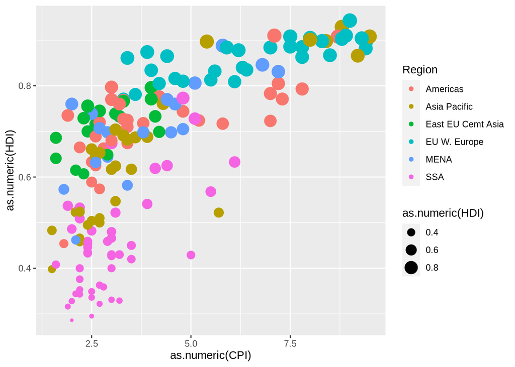

```r
ggplot(homework2, aes(y = as.numeric(HDI),  x = as.numeric(CPI))) +
  geom_point(aes(color = Region, size = as.numeric(HDI)))
```

5. Inclua nomes nos eixos x e y, um título para o seu gráfico bem como legendas que julgar necessárias.

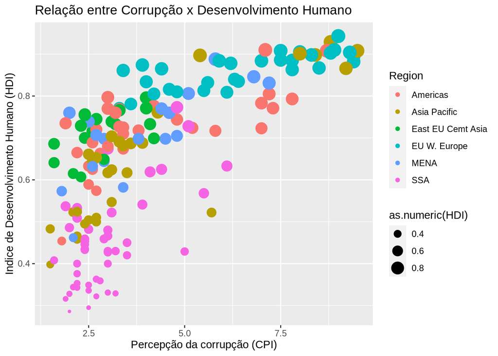

```r
ggplot(homework2, aes(y = as.numeric(HDI),  x = as.numeric(CPI))) +
  geom_point(aes(color = Region, size = as.numeric(HDI)))  +
  labs(y = "Indice de Desenvolvimento Humano (HDI)",
    x = "Percepção da corrupção (CPI)",
    title = "Relação entre Corrupção x Desenvolvimento Humano")
```

6. Desafio
- O gráfico abaixo foi publicado na revista The Economist e utiliza os dados contidos no arquivo que estamos usando.
- Escreva um código no R usando ggplot que replica tão próximo quanto possível o gráfico em questão.

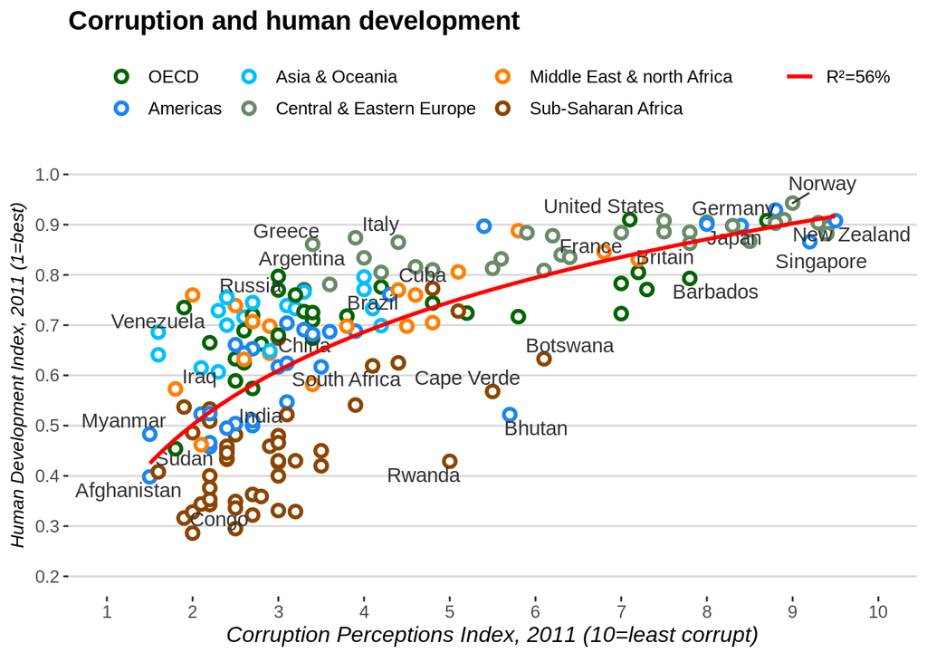

```r
x_title = expression (paste(italic("Corruption Perceptions Index, 2011 (10=least corrupt)")))
y_title = expression (paste(italic("Human Development Index, 2011 (1=best)")))
title   = expression (paste(bold("Corruption and human development")))
region_colors = c("darkgreen", "dodgerblue2","deepskyblue", "darkseagreen4", "darkorange1", "darkorange4")
region_names  = c("OECD", "Americas","Asia & Oceania", "Central & Eastern Europe", "Middle East & north Africa", "Sub-Saharan Africa")
# Select specific countries
pointsToLabel <- c("Russia", "Venezuela", "Iraq", "Myanmar", "Sudan",
                   "Afghanistan", "Congo", "Greece", "Argentina", "Brazil",
                   "India", "Italy", "China", "South Africa", "Spane",
                   "Botswana", "Cape Verde", "Bhutan", "Rwanda", "France",
                   "United States", "Germany", "Britain", "Barbados", "Norway", "Japan", "New Zealand", "Singapore", "Cuba")

ggplot(homework2, mapping = aes(y = as.numeric(HDI),  x = as.numeric(CPI))) +
  geom_point(aes(color = Region), fill="white", pch=21, size=2, stroke=1.5) +
  labs(y = y_title,
       x = x_title,
       title = title)  +
  theme_hc() +
  geom_text_repel(aes(label = Country), color = 'gray20',
                       data=subset(homework2, Country %in% pointsToLabel),
                       check_overlap = TRUE) +
  theme(legend.position = "top", axis.title.y = element_text(size = 10), legend.box = "horizontal") +
  scale_linetype_manual(name = "", values = c("R²=56%" = "solid")) +
  scale_y_continuous(limits = c(0.2,1), breaks =seq(0.2,1,0.1)) +
  scale_x_continuous(limits = c(1,10), breaks =seq(1,10,1)) +
  scale_color_manual(name = "", values = region_colors, labels = region_names) +
  geom_smooth(se = FALSE, method = "lm", aes(linetype = "R²=56%"), color="red", formula = y ~ log(x))  # <-- geom_smooth para acrescentar uma linha no grafico
```

6. Desafio (comecou assim…)
- O gráfico abaixo foi publicado na revista The Economist e utiliza os dados contidos no arquivo que estamos usando.
- Escreva um código no R usando ggplot que replica tão próximo quanto possível o gráfico em questão.

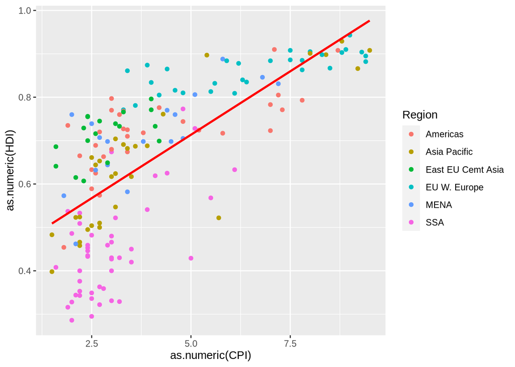

```r
ggplot(homework2, mapping = aes(y = as.numeric(HDI),  x = as.numeric(CPI))) +
  geom_point(aes(color = Region)) +
  geom_smooth(se = FALSE, method = "lm", color="red")
```